# SDS_HW2_G40

Debodeep Banerjee (1901253) and Trina Sahoo (1901254)

## 1. Importing the Dataset

The dataset depend on the right brain and left brain. The problem is to evaluate the dependency between the cortical region.

```r
knitr::opts_chunk$set(echo = TRUE)

#########################################Importing the Data############################################

data=load("~/Sapienza Learning Materials/SDS 1 Homework/sdshw2/hw2_data.RData")
data=mts
D=ncol(data)
n=nrow(data)
```

## 2. Application of simultaneous bootstrapped confidence intervals for a generic association measure row

```r
knitr::opts_chunk$set(echo = TRUE)

###############simultaneous bootstrapped confidence intervals for a generic association measure row##################

#Correlation matrix

R_cap=cor(data)

# Dimension of the correlation matrix
dim(cor(data))
```

```
## [1] 81 81
```

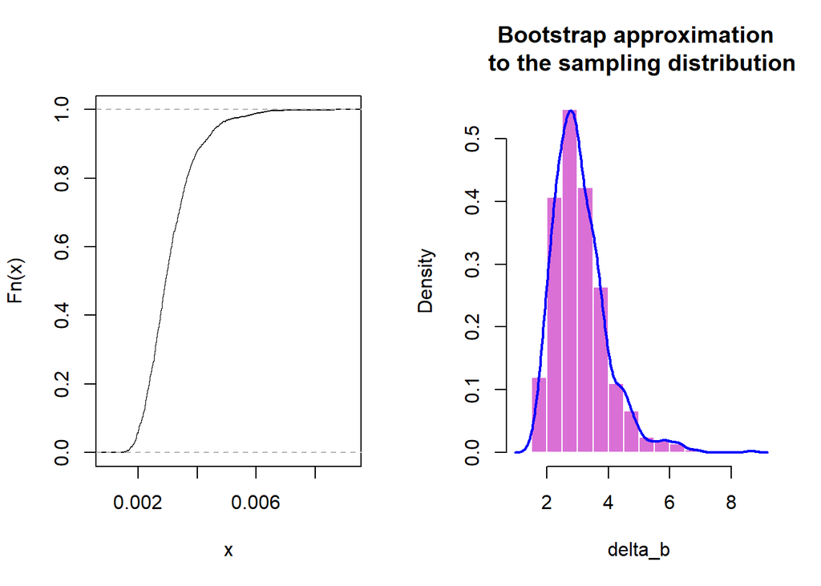

```r
# Number of bootstraps
B = 1000
delta_b = rep(NA, B)

for (b in 1:B){
  idx = sample(1:n, replace = T)
  bsamp   = data[idx,]        # bootstrap sample
  R_star  = cor(bsamp)        # save
  delta_b[b] = sqrt(n)*(max(abs(R_star-R_cap)))
}

# Bootstrap ECDF > G*(t)

Gstar = ecdf((1/B)*(delta_b))
par(mfrow=c(1,2))
plot(Gstar, main = "")
hist(delta_b,prob=TRUE, breaks = 25, col = "orchid", border = "white",

     main = "Bootstrap approximation \n to the sampling distribution")
lines(density(delta_b), col="blue", lwd=2) # add a density estimate with defaults
```

```r
knitr::opts_chunk$set(echo = TRUE)

# Bootstrap standard error
se_boot <- sqrt(var(delta_b))
se_boot
```

```
## [1] 0.8720829
```

```r
# Bootstrap /  CI / 95%
alpha=0.05
t_alpha <- quantile(delta_b, 1-alpha)
t_alpha
```

```
##      95%
## 4.643671
```

```r
lb=R_cap-(t_alpha/sqrt(n))
ub=R_cap+(t_alpha/sqrt(n))

# Write the function

R_mat=function(epsilon){
  Pmatrix = (lb>epsilon)+(ub< -(epsilon))
  Pmatrix
  sig_values=which(Pmatrix==1, arr.in= TRUE)
  # code to get the desired rowname and colname
  data1 <- data.frame(matrix(ncol = 3))
  x <- c('from','to' , "Correlation")

  i<-1
  #data1=data.frame(p1=character(),p2=character(),p3)
  while (i <= nrow(sig_values)){
    data1<-rbind(data1,c(rownames(R_cap)[sig_values[i,1]],colnames(R_cap)[sig_values[i,2]],
                         R_cap[sig_values[i,1],sig_values[i,2]]))
    i<-i+1
  }

  colnames(data1) <- x

  data1<-data1[-1,]
  data1$Correlation <- as.numeric(as.character(data1$Correlation))
  return(data1)
}
table=R_mat(0.69)
head(table)
```

```
##   from to Correlation
## 2   1R 1R   1.0000000
## 3   2R 2R   1.0000000
## 4  24R 2R   0.9921027
## 5  42R 2R   0.9913739
## 6  46R 2R   0.9911351
## 7  45L 2R  -0.9904177
```

```r
knitr::opts_chunk$set(echo = TRUE)
```

## 3. Graph Analysis

The below graph shows the connectivity between different portions of our brain. Here, the value of epsilon=0.69 and the connectivity between the hemisphere is clear and specific.

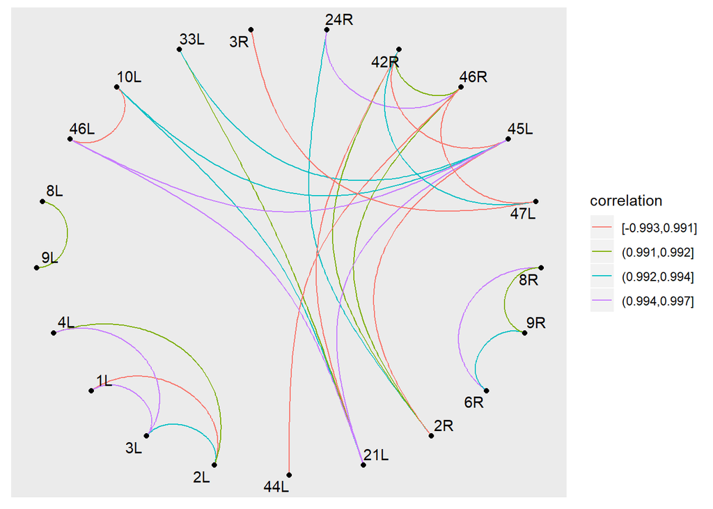

```r
knitr::opts_chunk$set(echo = TRUE)

#####  Plot the data #####
library(ggraph)
library(igraph)

only_sig <- table[abs(table$Correlation) !=1, ]
new_g <- graph_from_data_frame(only_sig, F)

correlation = cut_number((only_sig$ "Correlation"), 4)
col = c("#E1AF00", "#EBCC2A", "#78B7C5", "#3B9AB2")
names(col) = levels(correlation)
ggraph(new_g, layout = 'linear', circular = TRUE) +
  geom_edge_arc(aes(col=correlation))+
  geom_node_point() +
  geom_node_text(aes(label = name), repel=TRUE)
```

```r
knitr::opts_chunk$set(echo = TRUE)
```

### 3.1 Graph analysis at $\epsilon$=0.40 and $\epsilon$=0.65

As the value of epsilon decreases the connectivity of between and within hemisphere increases.

```r
knitr::opts_chunk$set(echo = TRUE)


table=R_mat(0.40)
head(table)
```

```
##   from to Correlation
## 2   1R 1R   1.0000000
## 3   2R 1R   0.9787156
## 4   3R 1R   0.9686066
## 5   6R 1R   0.9637880
## 6   8R 1R   0.9602842
## 7   9R 1R   0.9465585
```

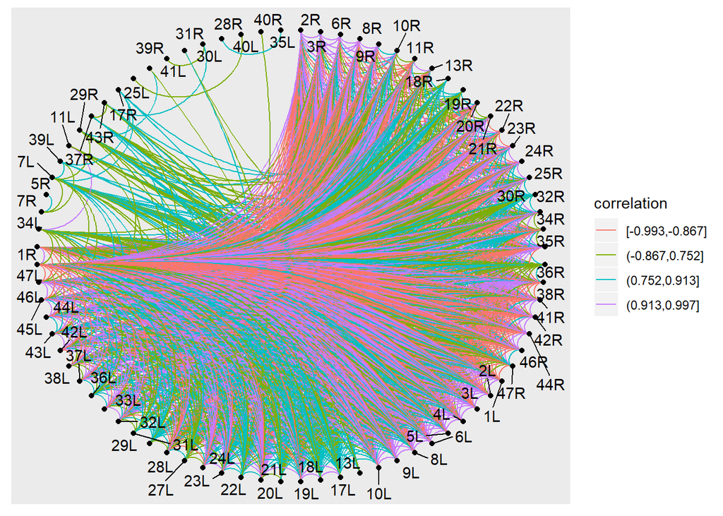

```r
#####  Plot the data #####

only_sig <- table[abs(table$Correlation) !=1, ]
new_g <- graph_from_data_frame(only_sig, F)

correlation = cut_number((only_sig$ "Correlation"), 4)
col = c("#E1AF00", "#EBCC2A", "#78B7C5", "#3B9AB2")
names(col) = levels(correlation)

ggraph(new_g, layout = 'linear', circular = TRUE) +
  geom_edge_arc(aes(col=correlation))+
  geom_node_point() +
  geom_node_text(aes(label = name), repel=TRUE)
```

```r
table=R_mat(0.65)
head(table)
```

```
##   from to Correlation
## 2   1R 1R   1.0000000
## 3   2R 1R   0.9787156
## 4   3R 1R   0.9686066
## 5   6R 1R   0.9637880
## 6   8R 1R   0.9602842
## 7  24R 1R   0.9618651
```

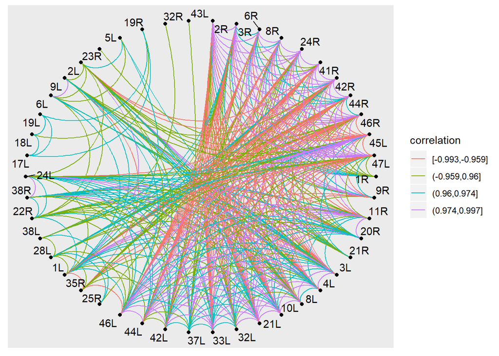

```r
#####  Plot the data #####

only_sig <- table[abs(table$Correlation) !=1, ]
new_g <- graph_from_data_frame(only_sig, F)

correlation = cut_number((only_sig$ "Correlation"), 4)
col = c("#E1AF00", "#EBCC2A", "#78B7C5", "#3B9AB2")
names(col) = levels(correlation)
ggraph(new_g, layout = 'linear', circular = TRUE) +
  geom_edge_arc(aes(col=correlation))+
  geom_node_point() +
  geom_node_text(aes(label = name), repel=TRUE)
```

```r
knitr::opts_chunk$set(echo = TRUE)
```

### Remarks

In this case we’ve used the pearson correlation method. The connectivity amongst the hemisphere and the value of the epsilon are inversely related. As the value of epsilon increases the connectivity between the hemisphere decreases and with the small value of epsilon the connectivity between the hemisphere is more. Moreover, if the value of the epsilon is really high, there exists no connectivity between and within the hemisphere.

# 4. Consider the partial correlation: Performing the same task using SIN package

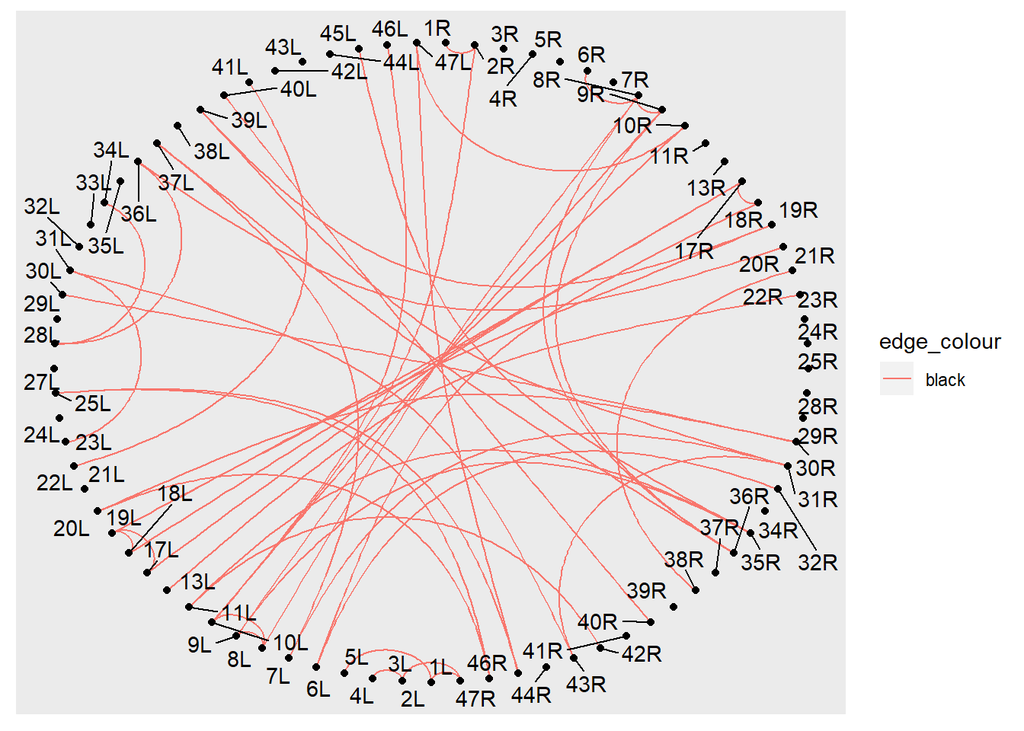

```r
knitr::opts_chunk$set(echo = TRUE)

###################### Partial Correlation########################


library(SIN)
out=sinUG(R_cap,nrow(data))
par(mfrow = c(1,2))
alpha = 0.05
E.SIN = getgraph(out, alpha)

G.SIN = graph.adjacency(E.SIN, mode = "undirected")
ggraph(G.SIN, layout = 'linear', circular = TRUE) +
  geom_edge_arc(aes(col= 'black'))+
  geom_node_point() +
  geom_node_text(aes(label = name), repel=TRUE)
```

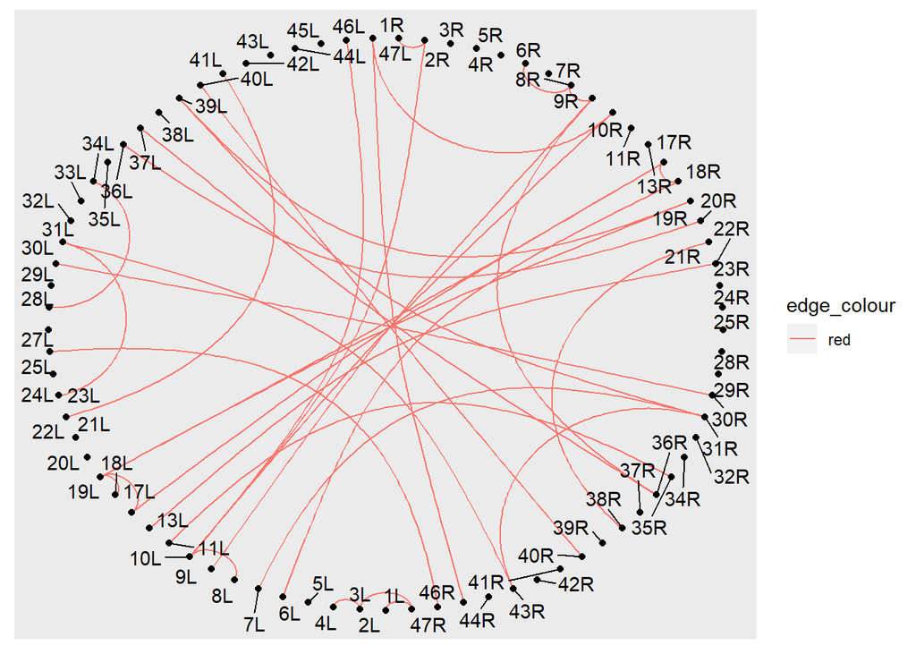

```r
alpha = 0.01
E.SIN = getgraph(out, alpha)

G.SIN = graph.adjacency(E.SIN, mode = "undirected")
#correlation = cut_number((only_sig$ "correlation"), 4)
col = c("#E1AF00", "#EBCC2A", "#78B7C5", "#3B9AB2")
#names(col) = levels(correlation)
ggraph(G.SIN, layout = 'linear', circular = TRUE) +
  geom_edge_arc(aes(col='red'))+
  geom_node_point() +
  geom_node_text(aes(label = name), repel=TRUE)
```

### Remarks:

Like, with the ci s we are chopping the lower correlation values but with the sin package we are chopping statically insignificant values.

```r
knitr::opts_chunk$set(echo = TRUE)
```

# 5. Additional exploration

## 5.1 Exploring the Right brain

As mentioned and shown in the above graph the connectivity between the hemisphere is quite clear. But in order to get a more clear picture of within the hemisphere we consider the right brain separately. The espilon value the same as 0.69 but the connectivity is more strong within the right hemisphere.

```r
knitr::opts_chunk$set(echo = TRUE)

                 ######################## Exploration #########################

                         ### Exploring the right portion of our brain ###

Data_right=data[,1:39]
R_cap.right=cor(Data_right)

# Number of bootstraps
B = 1000
delta_b = rep(NA, B)

for (b in 1:B){
  idx = sample(1:n, replace = T)
  bsamp   = Data_right[idx,]        # bootstrap sample
  R_star  = cor(bsamp)        # save
  delta_b[b] = sqrt(n)*(max(abs(R_star-R_cap.right)))
}

# Bootstrap /  CI / 95%
alpha=0.05
t_alpha <- quantile(delta_b, 1-alpha)
t_alpha
```

```
##      95%
## 3.978031
```

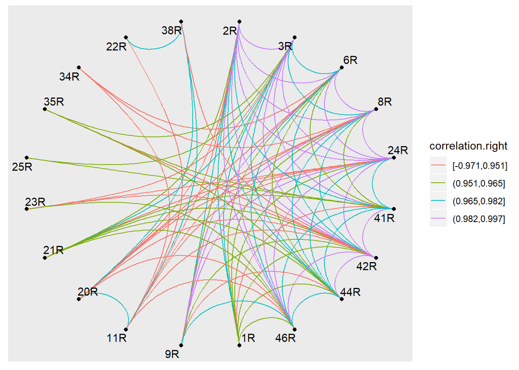

```r
lb.right=R_cap.right-(t_alpha/sqrt(n))
ub.right=R_cap.right+(t_alpha/sqrt(n))

# Write the function

R_mat=function(epsilon){
  Pmatrix = (lb.right>epsilon)+(ub.right< -(epsilon))
  Pmatrix
  sig_values=which(Pmatrix==1, arr.in= TRUE)
  # code to get the desired rowname and colname
  data1 <- data.frame(matrix(ncol = 3))
  x <- c('from','to' , "Correlation")

  i<-1
  #data1=data.frame(p1=character(),p2=character(),p3)
  while (i <= nrow(sig_values)){
    data1<-rbind(data1,c(rownames(R_cap.right)[sig_values[i,1]],colnames(R_cap.right)[sig_values[i,2]],
                         R_cap.right[sig_values[i,1],sig_values[i,2]]))
    i<-i+1
  }

  colnames(data1) <- x

  data1<-data1[-1,]
  data1$Correlation <- as.numeric(as.character(data1$Correlation))
  return(data1)
}
table.right=R_mat(0.69)


only_sig.right <- table.right[abs(table.right$Correlation) !=1, ]
new_g.right <- graph_from_data_frame(only_sig.right, F)

correlation.right = cut_number((only_sig.right$ "Correlation"), 4)
col = c("#E1AF00", "#EBCC2A", "#78B7C5", "#3B9AB2")
names(col) = levels(correlation.right)

par(mfrow=c(1,2))
ggraph(new_g.right, layout = 'linear', circular = TRUE) +
  geom_edge_arc(aes(col=correlation.right))+
  geom_node_point() +
  geom_node_text(aes(label = name), repel=TRUE)
```

## 5.2 Exploring the Left brain

Similarly, the connectivity within the left hemisphere is more strong and clearly visable, keeping the value of the epsilon same.

```r
knitr::opts_chunk$set(echo = TRUE)

                           ### Exploring the left portion of our brain ###

Data_left=data[,40:81]
R_cap.left=cor(Data_left)

# Number of bootstraps
B = 1000
delta_b = rep(NA, B)

for (b in 1:B){
  idx = sample(1:n, replace = T)
  bsamp   = Data_left[idx,]        # bootstrap sample
  R_star  = cor(bsamp)        # save
  delta_b[b] = sqrt(n)*(max(abs(R_star-R_cap.left)))
}

# Bootstrap /  CI / 95%
alpha=0.05
t_alpha <- quantile(delta_b, 1-alpha)
t_alpha
```

```
##      95%
## 4.292681
```

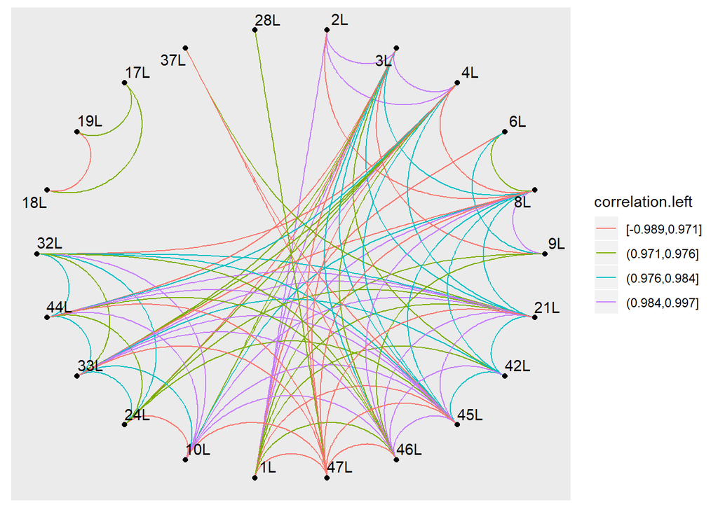

```r
lb.left=R_cap.left-(t_alpha/sqrt(n))
ub.left=R_cap.left+(t_alpha/sqrt(n))

# Write the function

R_mat=function(epsilon){
  Pmatrix = (lb.left>epsilon)+(ub.left< -(epsilon))
  Pmatrix
  sig_values=which(Pmatrix==1, arr.in= TRUE)
  # code to get the desired rowname and colname
  data1 <- data.frame(matrix(ncol = 3))
  x <- c('from','to' , "Correlation")

  i<-1
  #data1=data.frame(p1=character(),p2=character(),p3)
  while (i <= nrow(sig_values)){
    data1<-rbind(data1,c(rownames(R_cap.left)[sig_values[i,1]],colnames(R_cap.left)[sig_values[i,2]],
                         R_cap.left[sig_values[i,1],sig_values[i,2]]))
    i<-i+1
  }

  colnames(data1) <- x

  data1<-data1[-1,]
  data1$Correlation <- as.numeric(as.character(data1$Correlation))
  return(data1)
}
table.left=R_mat(0.69)


only_sig.left <- table.left[abs(table.left$Correlation) !=1, ]
new_g.left <- graph_from_data_frame(only_sig.left, F)

correlation.left = cut_number((only_sig.left$ "Correlation"), 4)

col = c("#E1AF00", "#EBCC2A", "#78B7C5", "#3B9AB2")
names(col) = levels(correlation.left)
ggraph(new_g.left, layout = 'linear', circular = TRUE) +
  geom_edge_arc(aes(col=correlation.left))+
  geom_node_point() +
  geom_node_text(aes(label = name), repel=TRUE)
```

```r
knitr::opts_chunk$set(echo = TRUE)

# Some numerical comparisons between the left and the right portions.

### Lenth:
length=c(length(only_sig.left$Correlation),length(only_sig.right$Correlation))

### Maximum and minimum
max=c(max(only_sig.left$Correlation),max(only_sig.right$Correlation))
min=c(min(only_sig.left$Correlation),min(only_sig.right$Correlation))

dataframe=data.frame(length,max,min)
rownames(dataframe)=c("Left_Part","Right_Part")
dataframe
```

```
##            length       max        min
## Left_Part     182 0.9973952 -0.9886874
## Right_Part    180 0.9968595 -0.9710428
```